```python
from google.colab import drive
drive.mount('/content/drive')
```

# Introduction

We will create a dataset of 200000 instances seperated into 5 classes. Each instance will have 97 features with roughly a quarter of them being redundant. Also, 40% of the instances will have a random class assigned, that is, there is an error of 40%. Throughout this notebook we will analyse the data and build the most appropriate model to classify this data.

```python
import numpy as np
import pandas as pd
import sklearn as sk
from sklearn.datasets import make_classification

import tensorflow as tf
from tensorflow import keras
from tensorflow.keras.utils import to_categorical
from tensorflow.keras.models import Sequential
from tensorflow.keras.layers import Dense
from tensorflow.keras.layers import Dropout
import matplotlib.pyplot as plt

from tensorflow.keras.wrappers.scikit_learn import KerasClassifier
from sklearn.model_selection import GridSearchCV

# CNN Memory limits
physical_devices = tf.config.list_physical_devices('GPU')
tf.config.experimental.set_memory_growth(physical_devices[0], True)
```

# Creating dataset

Like we mentioned previously, we will create a dataset with our assigned variabled. To do this, we will use sklearn's make_classification function. Once created, we will save the data to a csv file so we don't have to create new data everytime. Also, if we did create new data everytime, we couldn't compare the models properly as there would be models trained and tested with different data.

```python
# User values
seed = 76
np.random.seed(seed)
tf.random.set_seed(seed)


features = 97
classes = 5
n = 200000
errors = 0.4
redundant = int(features/4)


# Classification dataset
X, y = make_classification(n_samples=n, n_classes=classes, n_features=features, \
                           random_state = 1,n_informative =20, flip_y=errors, \
                           n_redundant=redundant)

# reshape y to 2D array, it needs to be to append
y = np.reshape(y, (-1, 1))

#add y to x
Xy = np.concatenate((X,y),axis=1)

# Commented to avoid rewriting file
np.savetxt("myCAData.csv", Xy, delimiter=",")

print(Xy[:5])
```

[output not shown]

# Data visualisation and Exploration

```python
# data = pd.read_csv("myCAData.csv", header=None)
data = pd.read_csv("/content/drive/MyDrive/UNI/AIIDL/myCAData.csv", header=None)

data = sk.utils.shuffle(data, random_state=1)

dataset = data.values

X = dataset[:,0:97]
y = dataset[:,97:]

data.describe()
```

|  | 0 | 1 | 2 | 3 | 4 | 5 | 6 | 7 | 8 | 9 | ... | 88 | 89 | 90 | 91 | 92 | 93 | 94 | 95 | 96 | 97 |
| --- | --- | --- | --- | --- | --- | --- | --- | --- | --- | --- | --- | --- | --- | --- | --- | --- | --- | --- | --- | --- | --- |
| count | 200000.000000 | 200000.000000 | 200000.000000 | 200000.000000 | 200000.000000 | 200000.000000 | 200000.000000 | 200000.000000 | 200000.000000 | 200000.000000 | ... | 200000.000000 | 200000.000000 | 200000.000000 | 200000.000000 | 200000.000000 | 200000.000000 | 200000.000000 | 200000.000000 | 200000.000000 | 200000.000000 |
| mean | 0.001529 | -0.001550 | -0.213018 | 0.002077 | -0.402899 | 0.066625 | 0.002855 | -0.002997 | 0.394157 | 0.000732 | ... | -0.896409 | -0.002598 | -0.000811 | -0.000951 | 0.002125 | -0.810080 | -0.003411 | 1.661858 | 0.000913 | 1.996425 |
| std | 0.999573 | 0.999988 | 7.169122 | 1.002356 | 2.696222 | 6.116355 | 0.999096 | 0.998033 | 2.628184 | 0.999268 | ... | 7.467795 | 1.002344 | 1.000238 | 1.001299 | 0.996637 | 2.672964 | 2.880673 | 6.231575 | 1.001327 | 1.415423 |
| min | -4.591173 | -4.577125 | -36.835904 | -5.117787 | -12.385213 | -30.486187 | -4.280239 | -4.846135 | -10.670023 | -4.639715 | ... | -37.531757 | -4.517139 | -4.574006 | -4.654048 | -4.761254 | -12.675463 | -14.082772 | -27.189580 | -4.447287 | 0.000000 |
| 25% | -0.674839 | -0.676805 | -5.009151 | -0.675187 | -2.228684 | -3.869290 | -0.671331 | -0.678295 | -1.370184 | -0.674221 | ... | -5.926578 | -0.677463 | -0.678194 | -0.676600 | -0.667072 | -2.595944 | -1.904931 | -2.509328 | -0.676973 | 1.000000 |
| 50% | 0.003309 | -0.001480 | -0.301116 | 0.002306 | -0.426210 | 0.046744 | 0.002321 | -0.005006 | 0.409508 | 0.000009 | ... | -0.863268 | -0.003705 | -0.000491 | -0.004504 | 0.004960 | -0.853785 | 0.039340 | 1.631412 | 0.000711 | 2.000000 |
| 75% | 0.674507 | 0.670957 | 4.528433 | 0.678138 | 1.400780 | 4.035251 | 0.675785 | 0.670456 | 2.165148 | 0.675148 | ... | 4.171822 | 0.672834 | 0.673148 | 0.674804 | 0.675719 | 0.909146 | 1.937921 | 5.813068 | 0.675978 | 3.000000 |
| max | 5.004414 | 5.098656 | 35.652978 | 4.342199 | 13.682506 | 32.431418 | 5.359334 | 4.365063 | 11.640365 | 4.979295 | ... | 33.640470 | 4.483422 | 4.303452 | 4.562670 | 4.390344 | 15.005944 | 12.720815 | 29.817840 | 4.684418 | 4.000000 |

8 rows × 98 columns

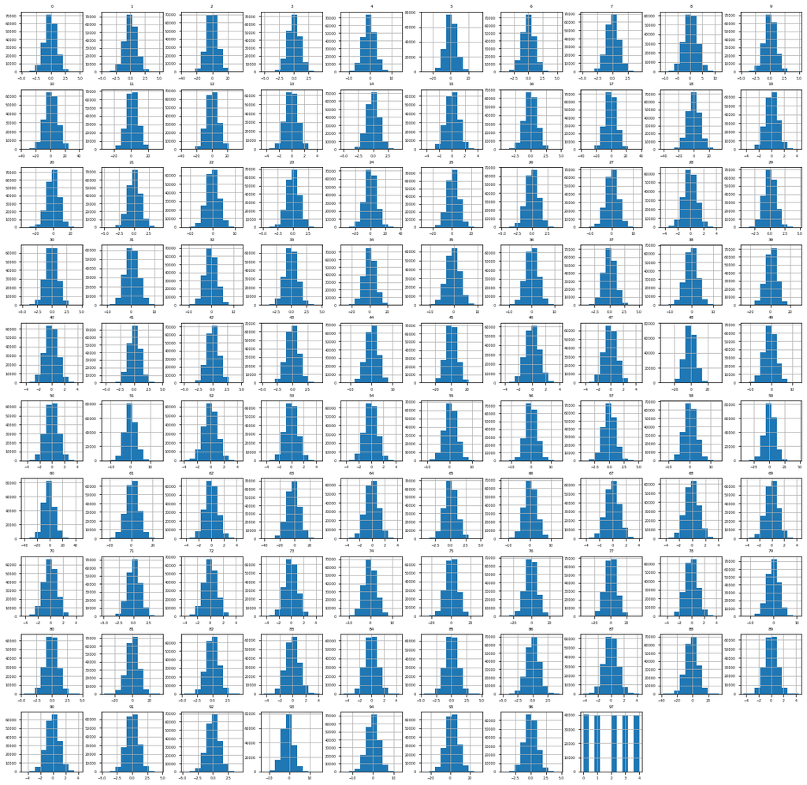

```python
plt.rc('font', size=5)
data.hist(figsize=(20,20))
plt.show()
```

As we can observe, most of the data if not all, follow a normal distribution with very little skew or outliers. And despite 40% of the instances being assigned a random class, there seems to be an almost equal distribution among the classes. However, we will calculate the number of instances per class in the next cell to confirm this.

```python
unique, counts = np.unique(y, return_counts=True)
print("Class proportions")
dict(zip(unique, 100*counts/len(y)))
```

```
Class proportions
```

```
{0.0: 20.1145, 1.0: 20.016, 2.0: 19.9725, 3.0: 19.9065, 4.0: 19.9905}
```

There are some classes with slightly more representation than others, however, the difference in proportions can be considered to be negligeable.

```python
corr = data.corr()
with pd.option_context('display.max_rows', None, 'display.max_columns', None):
    print(corr[97].sort_values(ascending=False)[:10])
corr.style.background_gradient().set_precision(2)
```

```
97    1.000000
88    0.152297
27    0.121269
60    0.100777
18    0.099088
36    0.088087
2     0.078389
48    0.072162
55    0.064294
93    0.063508
Name: 97, dtype: float64
```

|  | 0 | 1 | 2 | 3 | 4 | 5 | 6 | 7 | 8 | 9 | 10 | 11 | 12 | 13 | 14 | 15 | 16 | 17 | 18 | 19 | 20 | 21 | 22 | 23 | 24 | 25 | 26 | 27 | 28 | … |
| --- | --- | --- | --- | --- | --- | --- | --- | --- | --- | --- | --- | --- | --- | --- | --- | --- | --- | --- | --- | --- | --- | --- | --- | --- | --- | --- | --- | --- | --- | --- |
| 0 | 1.00 | -0.00 | 0.00 | -0.00 | -0.00 | -0.00 | 0.00 | 0.00 | -0.00 | -0.00 | 0.00 | 0.00 | 0.00 | -0.00 | 0.00 | -0.01 | 0.00 | -0.00 | 0.00 | 0.00 | 0.00 | -0.00 | -0.00 | -0.00 | -0.00 | -0.00 | -0.00 | 0.00 | -0.00 | … |
| 1 | -0.00 | 1.00 | 0.00 | 0.00 | -0.00 | -0.00 | 0.00 | 0.00 | 0.00 | 0.00 | -0.00 | 0.00 | 0.01 | 0.00 | 0.00 | 0.00 | -0.00 | -0.01 | -0.00 | -0.00 | -0.00 | -0.00 | -0.00 | -0.00 | 0.00 | -0.00 | -0.00 | 0.00 | -0.00 | … |
| 2 | 0.00 | 0.00 | 1.00 | -0.00 | 0.37 | -0.00 | -0.00 | -0.00 | -0.22 | 0.00 | 0.02 | -0.06 | 0.17 | -0.00 | -0.00 | 0.00 | 0.00 | -0.25 | 0.28 | -0.00 | 0.25 | -0.00 | 0.27 | -0.00 | 0.22 | 0.07 | 0.00 | 0.17 | -0.00 | … |
| 3 | -0.00 | 0.00 | -0.00 | 1.00 | 0.00 | 0.00 | 0.00 | -0.00 | -0.00 | 0.00 | -0.00 | 0.00 | -0.00 | 0.00 | 0.00 | -0.00 | -0.00 | -0.00 | 0.00 | 0.00 | 0.00 | -0.00 | -0.00 | -0.00 | 0.00 | -0.00 | -0.00 | -0.00 | -0.00 | … |
| 4 | -0.00 | -0.00 | 0.37 | 0.00 | 1.00 | -0.17 | -0.00 | -0.00 | 0.06 | 0.00 | 0.17 | -0.29 | 0.28 | -0.00 | -0.00 | 0.00 | 0.00 | -0.26 | 0.18 | -0.00 | -0.06 | 0.00 | -0.05 | -0.00 | 0.36 | 0.37 | -0.00 | -0.06 | 0.00 | … |
| 5 | -0.00 | -0.00 | -0.00 | 0.00 | -0.17 | 1.00 | 0.00 | 0.00 | -0.20 | 0.00 | -0.14 | 0.18 | 0.18 | -0.00 | -0.00 | -0.00 | 0.00 | 0.24 | -0.13 | -0.00 | 0.01 | -0.00 | 0.12 | -0.00 | 0.30 | 0.04 | 0.00 | -0.07 | -0.00 | … |
| 6 | 0.00 | 0.00 | -0.00 | 0.00 | -0.00 | 0.00 | 1.00 | 0.00 | 0.00 | -0.00 | -0.00 | -0.00 | -0.00 | -0.00 | -0.00 | -0.00 | -0.00 | -0.00 | -0.00 | 0.00 | -0.00 | -0.00 | -0.00 | 0.01 | -0.00 | 0.00 | 0.00 | 0.00 | -0.00 | … |
| 7 | 0.00 | 0.00 | -0.00 | -0.00 | -0.00 | 0.00 | 0.00 | 1.00 | -0.00 | 0.00 | 0.00 | 0.00 | 0.00 | 0.00 | -0.00 | 0.00 | 0.00 | 0.00 | 0.00 | -0.00 | -0.00 | 0.00 | 0.00 | -0.00 | 0.00 | -0.00 | -0.00 | -0.00 | -0.00 | … |
| 8 | -0.00 | 0.00 | -0.22 | -0.00 | 0.06 | -0.20 | 0.00 | -0.00 | 1.00 | -0.00 | 0.10 | 0.28 | 0.11 | 0.00 | 0.00 | 0.00 | 0.00 | -0.20 | -0.38 | -0.00 | -0.25 | 0.00 | -0.09 | -0.00 | 0.17 | -0.01 | 0.00 | -0.12 | 0.00 | … |
| 9 | -0.00 | 0.00 | 0.00 | 0.00 | 0.00 | 0.00 | -0.00 | 0.00 | -0.00 | 1.00 | -0.00 | -0.00 | -0.00 | -0.00 | -0.00 | 0.00 | -0.00 | -0.00 | -0.00 | -0.00 | 0.00 | 0.00 | -0.00 | -0.00 | 0.00 | -0.00 | 0.00 | -0.00 | 0.00 | … |
| 10 | 0.00 | -0.00 | 0.02 | -0.00 | 0.17 | -0.14 | -0.00 | 0.00 | 0.10 | -0.00 | 1.00 | 0.29 | 0.34 | -0.00 | -0.00 | 0.00 | -0.00 | 0.38 | 0.02 | -0.00 | 0.24 | -0.00 | 0.21 | 0.00 | 0.08 | 0.40 | -0.00 | 0.04 | 0.00 | … |
| 11 | 0.00 | 0.00 | -0.06 | 0.00 | -0.29 | 0.18 | -0.00 | 0.00 | 0.28 | -0.00 | 0.29 | 1.00 | 0.15 | 0.00 | 0.00 | 0.00 | 0.00 | 0.16 | -0.41 | -0.00 | 0.25 | -0.00 | -0.17 | 0.00 | 0.03 | 0.15 | 0.00 | -0.30 | -0.00 | … |
| 12 | 0.00 | 0.01 | 0.17 | -0.00 | 0.28 | 0.18 | -0.00 | 0.00 | 0.11 | -0.00 | 0.34 | 0.15 | 1.00 | -0.00 | -0.00 | 0.00 | -0.00 | 0.14 | -0.00 | -0.00 | 0.09 | 0.00 | 0.05 | -0.00 | 0.29 | 0.11 | -0.00 | 0.16 | -0.00 | … |
| 13 | -0.00 | 0.00 | -0.00 | 0.00 | -0.00 | -0.00 | -0.00 | 0.00 | 0.00 | -0.00 | -0.00 | 0.00 | -0.00 | 1.00 | 0.00 | 0.01 | 0.00 | 0.00 | -0.00 | -0.00 | -0.00 | 0.00 | -0.00 | 0.00 | -0.01 | -0.00 | -0.00 | -0.00 | -0.00 | … |
| 14 | 0.00 | 0.00 | -0.00 | 0.00 | -0.00 | -0.00 | -0.00 | -0.00 | 0.00 | -0.00 | -0.00 | 0.00 | -0.00 | 0.00 | 1.00 | 0.00 | -0.01 | -0.01 | -0.00 | -0.00 | -0.00 | -0.00 | -0.00 | 0.00 | -0.00 | -0.00 | -0.00 | 0.00 | 0.00 | … |
| 15 | -0.01 | 0.00 | 0.00 | -0.00 | 0.00 | -0.00 | -0.00 | 0.00 | 0.00 | 0.00 | 0.00 | 0.00 | 0.00 | 0.01 | 0.00 | 1.00 | -0.00 | -0.00 | 0.00 | 0.00 | 0.00 | 0.00 | 0.00 | 0.00 | 0.00 | -0.00 | -0.00 | -0.00 | -0.00 | … |
| 16 | 0.00 | -0.00 | 0.00 | -0.00 | 0.00 | 0.00 | -0.00 | 0.00 | 0.00 | -0.00 | -0.00 | 0.00 | -0.00 | 0.00 | -0.01 | -0.00 | 1.00 | -0.00 | 0.00 | -0.00 | -0.00 | -0.00 | -0.00 | 0.00 | -0.00 | 0.00 | -0.00 | -0.00 | 0.00 | … |
| 17 | -0.00 | -0.01 | -0.25 | -0.00 | -0.26 | 0.24 | -0.00 | 0.00 | -0.20 | -0.00 | 0.38 | 0.16 | 0.14 | 0.00 | -0.01 | -0.00 | -0.00 | 1.00 | -0.31 | -0.00 | 0.14 | 0.00 | 0.22 | 0.00 | -0.17 | -0.00 | -0.00 | -0.13 | -0.00 | … |
| 18 | 0.00 | -0.00 | 0.28 | 0.00 | 0.18 | -0.13 | -0.00 | 0.00 | -0.38 | -0.00 | 0.02 | -0.41 | -0.00 | -0.00 | -0.00 | 0.00 | 0.00 | -0.31 | 1.00 | 0.00 | 0.13 | -0.00 | 0.27 | -0.00 | 0.03 | 0.18 | 0.00 | 0.31 | 0.00 | … |
| 19 | 0.00 | -0.00 | -0.00 | 0.00 | -0.00 | -0.00 | 0.00 | -0.00 | -0.00 | -0.00 | -0.00 | -0.00 | -0.00 | -0.00 | -0.00 | 0.00 | -0.00 | -0.00 | 0.00 | 1.00 | -0.00 | 0.00 | -0.00 | -0.00 | -0.00 | -0.00 | -0.00 | -0.00 | 0.00 | … |
| 20 | 0.00 | -0.00 | 0.25 | 0.00 | -0.06 | 0.01 | -0.00 | -0.00 | -0.25 | 0.00 | 0.24 | 0.25 | 0.09 | -0.00 | -0.00 | 0.00 | -0.00 | 0.14 | 0.13 | -0.00 | 1.00 | -0.00 | 0.29 | 0.00 | -0.03 | 0.13 | -0.00 | -0.01 | -0.00 | … |
| 21 | -0.00 | -0.00 | -0.00 | -0.00 | 0.00 | -0.00 | -0.00 | 0.00 | 0.00 | 0.00 | -0.00 | -0.00 | 0.00 | 0.00 | -0.00 | 0.00 | -0.00 | 0.00 | -0.00 | 0.00 | -0.00 | 1.00 | 0.00 | -0.00 | -0.00 | -0.00 | 0.00 | -0.00 | 0.00 | … |
| 22 | -0.00 | -0.00 | 0.27 | -0.00 | -0.05 | 0.12 | -0.00 | 0.00 | -0.09 | -0.00 | 0.21 | -0.17 | 0.05 | -0.00 | -0.00 | 0.00 | -0.00 | 0.22 | 0.27 | -0.00 | 0.29 | 0.00 | 1.00 | -0.00 | 0.32 | -0.14 | 0.00 | 0.01 | 0.00 | … |
| 23 | -0.00 | -0.00 | -0.00 | -0.00 | -0.00 | -0.00 | 0.01 | -0.00 | -0.00 | -0.00 | 0.00 | 0.00 | -0.00 | 0.00 | 0.00 | 0.00 | 0.00 | 0.00 | -0.00 | -0.00 | 0.00 | -0.00 | -0.00 | 1.00 | -0.00 | -0.00 | -0.00 | -0.00 | -0.00 | … |
| 24 | -0.00 | 0.00 | 0.22 | 0.00 | 0.36 | 0.30 | -0.00 | 0.00 | 0.17 | 0.00 | 0.08 | 0.03 | 0.29 | -0.01 | -0.00 | 0.00 | -0.00 | -0.17 | 0.03 | -0.00 | -0.03 | -0.00 | 0.32 | -0.00 | 1.00 | 0.09 | 0.00 | -0.09 | 0.00 | … |
| 25 | -0.00 | -0.00 | 0.07 | -0.00 | 0.37 | 0.04 | 0.00 | -0.00 | -0.01 | -0.00 | 0.40 | 0.15 | 0.11 | -0.00 | -0.00 | -0.00 | 0.00 | -0.00 | 0.18 | -0.00 | 0.13 | -0.00 | -0.14 | -0.00 | 0.09 | 1.00 | -0.00 | -0.02 | -0.00 | … |
| 26 | -0.00 | -0.00 | 0.00 | -0.00 | -0.00 | 0.00 | 0.00 | -0.00 | 0.00 | 0.00 | -0.00 | 0.00 | -0.00 | -0.00 | -0.00 | -0.00 | -0.00 | -0.00 | 0.00 | -0.00 | -0.00 | 0.00 | 0.00 | -0.00 | 0.00 | -0.00 | 1.00 | -0.00 | -0.00 | … |
| 27 | 0.00 | 0.00 | 0.17 | -0.00 | -0.06 | -0.07 | 0.00 | -0.00 | -0.12 | -0.00 | 0.04 | -0.30 | 0.16 | -0.00 | 0.00 | -0.00 | -0.00 | -0.13 | 0.31 | -0.00 | -0.01 | -0.00 | 0.01 | -0.00 | -0.09 | -0.02 | -0.00 | 1.00 | -0.00 | … |
| 28 | -0.00 | -0.00 | -0.00 | -0.00 | 0.00 | -0.00 | -0.00 | -0.00 | 0.00 | 0.00 | 0.00 | -0.00 | -0.00 | -0.00 | 0.00 | -0.00 | 0.00 | -0.00 | 0.00 | 0.00 | -0.00 | 0.00 | 0.00 | -0.00 | 0.00 | -0.00 | -0.00 | -0.00 | 1.00 | … |
| 29 | 0.00 | -0.00 | 0.00 | -0.00 | 0.00 | -0.00 | 0.00 | -0.00 | 0.00 | 0.00 | -0.00 | -0.00 | 0.00 | 0.00 | -0.00 | 0.00 | -0.00 | -0.00 | -0.00 | -0.01 | -0.00 | 0.00 | 0.00 | 0.00 | 0.01 | -0.00 | -0.00 | -0.00 | 0.00 | … |

[output cut: 68 more lines]

From the information available above, we can see that there is very little correlation between any of the features and the class variable. This could result in the accuracy of the model being fairly low as it seems there are no attributes that could have an effect on the class attribute.

# Data preprocessing

From the data exploration, we can observe that the distribution of the features is fairly normal with few outliers. Also, as it is a randomised dataset, the features have no real meaning. Therefore, we cannot identify any wrong or impossible values.

However, there is one preprocessing technique we will apply to improve the performance and make the training of the models more efficient. We will normalise the data.

```python
normData=(data-data.mean())/data.std()
dataset = normData.values

X = dataset[:,0:97]
```

# Model Exploration

### Model 1

With model 1, we start with a basic neural network with 2 layers, an input layer and an output layer. The activation function for the input layer is ReLU and for the output layer it is softmax. The output layer will have the same activation function throughout the rest of the notebook. The input layer activation function may change. We will train this model for 10 epochs at the default batch size of 32 using Adam as its optimizer.

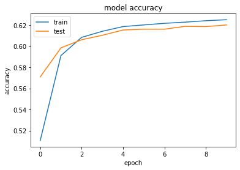

```python
# enocde values to categorical from Int.
encoded_y = to_categorical(y)


# define and fit the final model
model = Sequential()
model.add(Dense(50, input_dim=97, activation='relu'))
model.add(Dense(5, activation='softmax'))

model.compile(loss='categorical_crossentropy', optimizer='adam', metrics=['acc'])
history = model.fit(X, encoded_y, validation_split=0.33,epochs=10)


# summarize history for accuracy
plt.plot(history.history['acc'])
plt.plot(history.history['val_acc'])
plt.title('model accuracy')
plt.ylabel('accuracy')
plt.xlabel('epoch')
plt.legend(['train', 'test'], loc='upper left')
plt.show()
```

### Model 2

In an attempt to increase the performance, we will make the network larger by increasing the layers and the number of neurons per layer.

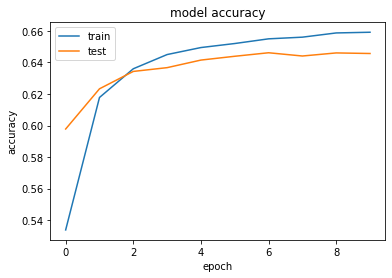

```python
# enocde values to categorical from Int.
encoded_y = to_categorical(y)


# define and fit the final model
model = Sequential()
model.add(Dense(50, input_dim=97, activation='relu'))
model.add(Dense(125, activation='relu'))
model.add(Dense(50, activation='relu'))
model.add(Dense(5, activation='softmax'))


model.compile(loss='categorical_crossentropy', optimizer='adam', metrics=['acc'])
history = model.fit(X, encoded_y, validation_split=0.33,epochs=10)


# summarize history for accuracy
plt.plot(history.history['acc'])
plt.plot(history.history['val_acc'])
plt.title('model accuracy')
plt.ylabel('accuracy')
plt.xlabel('epoch')
plt.legend(['train', 'test'], loc='upper left')
plt.show()
```

### Model 3

Although the previous model already seems to overfit, we are going to incease the height of the neural network to see if it improves the performance of the model.

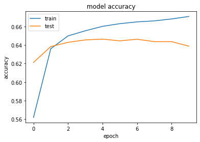

```python
# enocde values to categorical from Int.
encoded_y = to_categorical(y)


# define and fit the final model
model = Sequential()
model.add(Dense(125, input_dim=97, activation='relu'))
model.add(Dense(250, activation='relu'))
model.add(Dense(75, activation='relu'))
model.add(Dense(5, activation='softmax'))


model.compile(loss='categorical_crossentropy', optimizer='adam', metrics=['acc'])
history = model.fit(X, encoded_y, validation_split=0.33,epochs=10)


# summarize history for accuracy
plt.plot(history.history['acc'])
plt.plot(history.history['val_acc'])
plt.title('model accuracy')
plt.ylabel('accuracy')
plt.xlabel('epoch')
plt.legend(['train', 'test'], loc='upper left')
plt.show()
```

### Model 4

As the previouos 2 models seemed to be overfitting, we decided to reduce the height of the neural network. Hopefully, we will see the training accuracy and the validation accuracy come closer together.

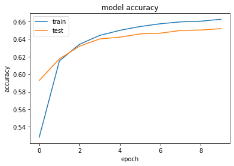

```python
# enocde values to categorical from Int.
encoded_y = to_categorical(y)


# define and fit the final model
model = Sequential()
model.add(Dense(75, input_dim=97, activation='relu'))
model.add(Dense(50, activation='relu'))
model.add(Dense(25, activation='relu'))
model.add(Dense(5, activation='softmax'))


model.compile(loss='categorical_crossentropy', optimizer='adam', metrics=['acc'])
history = model.fit(X, encoded_y, validation_split=0.33,epochs=10)


# summarize history for accuracy
plt.plot(history.history['acc'])
plt.plot(history.history['val_acc'])
plt.title('model accuracy')
plt.ylabel('accuracy')
plt.xlabel('epoch')
plt.legend(['train', 'test'], loc='upper left')
plt.show()
```

### Model 5

We reduce the height of the neural network to reduce more the overfitting. Also, we want to see if we can achieve the same or better performance using a computationally efficient model.

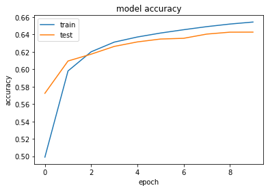

```python
# enocde values to categorical from Int.
encoded_y = to_categorical(y)


# define and fit the final model
model = Sequential()
model.add(Dense(50, input_dim=97, activation='relu'))
model.add(Dense(25, activation='relu'))
model.add(Dense(25, activation='relu'))
model.add(Dense(10, activation='relu'))
model.add(Dense(5, activation='softmax'))


model.compile(loss='categorical_crossentropy', optimizer='adam', metrics=['acc'])
history = model.fit(X, encoded_y, validation_split=0.33,epochs=10)


# summarize history for accuracy
plt.plot(history.history['acc'])
plt.plot(history.history['val_acc'])
plt.title('model accuracy')
plt.ylabel('accuracy')
plt.xlabel('epoch')
plt.legend(['train', 'test'], loc='upper left')
plt.show()
```

### Model 6

Now, we will use a similar topology but with the introduction of dropout layers to reduce overfitting. We are also using adamax to assess whether there is a noticeable difference between this and Adam.

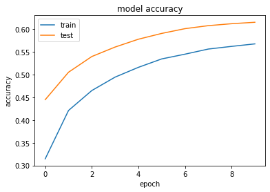

```python
# enocde values to categorical from Int.
encoded_y = to_categorical(y)


# define and fit the final model
model = Sequential()
model.add(Dense(50, input_dim=97, activation='relu'))
model.add(Dropout(0.2))
model.add(Dense(25, activation='relu'))
model.add(Dropout(0.2))
model.add(Dense(25, activation='relu'))
model.add(Dropout(0.2))
model.add(Dense(10, activation='relu'))
model.add(Dense(5, activation='softmax'))


model.compile(loss='categorical_crossentropy', optimizer='adamax', metrics=['acc'])
history = model.fit(X, encoded_y, validation_split=0.33,epochs=10)


# summarize history for accuracy
plt.plot(history.history['acc'])
plt.plot(history.history['val_acc'])
plt.title('model accuracy')
plt.ylabel('accuracy')
plt.xlabel('epoch')
plt.legend(['train', 'test'], loc='upper left')
plt.show()
```

### Model 7

We have converted the slight overfitting into underfitting. Therefore, we will now increase the height of the neural network and try and get to a balance between the 2 accuracies.

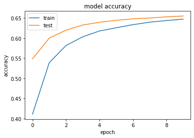

```python
# enocde values to categorical from Int.
encoded_y = to_categorical(y)


# define and fit the final model
model = Sequential()
model.add(Dense(250, input_dim=97, activation='relu'))
model.add(Dropout(0.2))
model.add(Dense(100, activation='relu'))
model.add(Dropout(0.2))
model.add(Dense(50, activation='relu'))
model.add(Dropout(0.2))
model.add(Dense(10, activation='relu'))
model.add(Dense(5, activation='softmax'))


model.compile(loss='categorical_crossentropy', optimizer='adamax', metrics=['acc'])
history = model.fit(X, encoded_y, validation_split=0.33,epochs=10)


# summarize history for accuracy
plt.plot(history.history['acc'])
plt.plot(history.history['val_acc'])
plt.title('model accuracy')
plt.ylabel('accuracy')
plt.xlabel('epoch')
plt.legend(['train', 'test'], loc='upper left')
plt.show()
```

I believe this is the best performance we will achieve by only modifying the topology and activation function. In the next section we will try this model with 8 different batch sizes.

# Batch Sizes

### Model 7.1

We will try with a batch size of 2000. Of course, by increasing the batch size, we also need to increase the number of epochs to ensure that there is a similar amount of training.

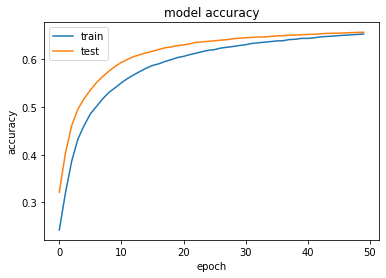

```python
# enocde values to categorical from Int.
encoded_y = to_categorical(y)


# define and fit the final model
model = Sequential()
model.add(Dense(250, input_dim=97, activation='relu'))
model.add(Dropout(0.2))
model.add(Dense(100, activation='relu'))
model.add(Dropout(0.2))
model.add(Dense(50, activation='relu'))
model.add(Dropout(0.2))
model.add(Dense(10, activation='relu'))
model.add(Dense(5, activation='softmax'))


model.compile(loss='categorical_crossentropy', optimizer='adamax', metrics=['acc'])
history = model.fit(X, encoded_y, validation_split=0.33,epochs=50, batch_size=2000)


# summarize history for accuracy
plt.plot(history.history['acc'])
plt.plot(history.history['val_acc'])
plt.title('model accuracy')
plt.ylabel('accuracy')
plt.xlabel('epoch')
plt.legend(['train', 'test'], loc='upper left')
plt.show()
```

### Model 7.2

We decrease the batch size to 1500 and decrease the number of epochs to 45.

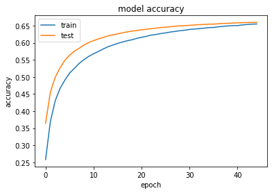

```python
# enocde values to categorical from Int.
encoded_y = to_categorical(y)


# define and fit the final model
model = Sequential()
model.add(Dense(250, input_dim=97, activation='relu'))
model.add(Dropout(0.2))
model.add(Dense(100, activation='relu'))
model.add(Dropout(0.2))
model.add(Dense(50, activation='relu'))
model.add(Dropout(0.2))
model.add(Dense(10, activation='relu'))
model.add(Dense(5, activation='softmax'))


model.compile(loss='categorical_crossentropy', optimizer='adamax', metrics=['acc'])
history = model.fit(X, encoded_y, validation_split=0.33,epochs=45, batch_size=1500)


# summarize history for accuracy
plt.plot(history.history['acc'])
plt.plot(history.history['val_acc'])
plt.title('model accuracy')
plt.ylabel('accuracy')
plt.xlabel('epoch')
plt.legend(['train', 'test'], loc='upper left')
plt.show()
```

### Model 7.3

We decrease the batch size to 1250 and decrease the number of epochs to 40.

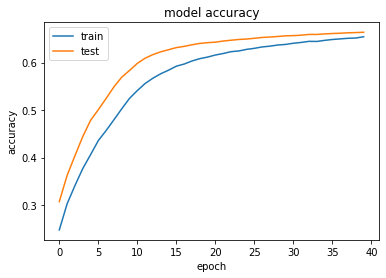

```python
# enocde values to categorical from Int.
encoded_y = to_categorical(y)


# define and fit the final model
model = Sequential()
model.add(Dense(250, input_dim=97, activation='relu'))
model.add(Dropout(0.2))
model.add(Dense(100, activation='relu'))
model.add(Dropout(0.2))
model.add(Dense(50, activation='relu'))
model.add(Dropout(0.2))
model.add(Dense(10, activation='relu'))
model.add(Dense(5, activation='softmax'))


model.compile(loss='categorical_crossentropy', optimizer='adamax', metrics=['acc'])
history = model.fit(X, encoded_y, validation_split=0.33, epochs=40, batch_size=1250)


# summarize history for accuracy
plt.plot(history.history['acc'])
plt.plot(history.history['val_acc'])
plt.title('model accuracy')
plt.ylabel('accuracy')
plt.xlabel('epoch')
plt.legend(['train', 'test'], loc='upper left')
plt.show()
```

### Model 7.4

We decrease the batch size to 1000 and maintain the number of epochs.

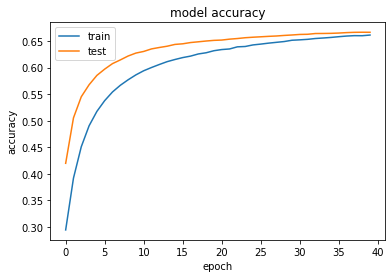

```python
# enocde values to categorical from Int.
encoded_y = to_categorical(y)


# define and fit the final model
model = Sequential()
model.add(Dense(250, input_dim=97, activation='relu'))
model.add(Dropout(0.2))
model.add(Dense(100, activation='relu'))
model.add(Dropout(0.2))
model.add(Dense(50, activation='relu'))
model.add(Dropout(0.2))
model.add(Dense(10, activation='relu'))
model.add(Dense(5, activation='softmax'))


model.compile(loss='categorical_crossentropy', optimizer='adamax', metrics=['acc'])
history = model.fit(X, encoded_y, validation_split=0.33, epochs=40, batch_size=1000)


# summarize history for accuracy
plt.plot(history.history['acc'])
plt.plot(history.history['val_acc'])
plt.title('model accuracy')
plt.ylabel('accuracy')
plt.xlabel('epoch')
plt.legend(['train', 'test'], loc='upper left')
plt.show()
```

### Model 7.5

We decrease the batch size to 600 and decrease the number of epochs to 30.

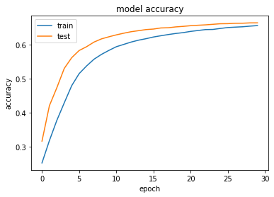

```python
# enocde values to categorical from Int.
encoded_y = to_categorical(y)


# define and fit the final model
model = Sequential()
model.add(Dense(250, input_dim=97, activation='relu'))
model.add(Dropout(0.2))
model.add(Dense(100, activation='relu'))
model.add(Dropout(0.2))
model.add(Dense(50, activation='relu'))
model.add(Dropout(0.2))
model.add(Dense(10, activation='relu'))
model.add(Dense(5, activation='softmax'))


model.compile(loss='categorical_crossentropy', optimizer='adamax', metrics=['acc'])
history = model.fit(X, encoded_y, validation_split=0.33, epochs=30, batch_size=600)


# summarize history for accuracy
plt.plot(history.history['acc'])
plt.plot(history.history['val_acc'])
plt.title('model accuracy')
plt.ylabel('accuracy')
plt.xlabel('epoch')
plt.legend(['train', 'test'], loc='upper left')
plt.show()
```

### Model 7.6

We decrease the batch size to 300 and decrease the number of epochs to 25.

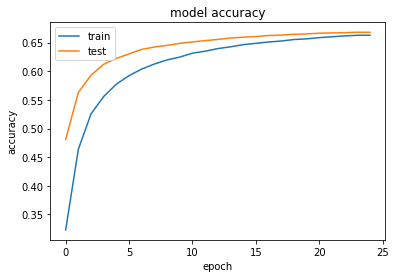

```python
# enocde values to categorical from Int.
encoded_y = to_categorical(y)


# define and fit the final model
model = Sequential()
model.add(Dense(250, input_dim=97, activation='relu'))
model.add(Dropout(0.2))
model.add(Dense(100, activation='relu'))
model.add(Dropout(0.2))
model.add(Dense(50, activation='relu'))
model.add(Dropout(0.2))
model.add(Dense(10, activation='relu'))
model.add(Dense(5, activation='softmax'))


model.compile(loss='categorical_crossentropy', optimizer='adamax', metrics=['acc'])
history = model.fit(X, encoded_y, validation_split=0.33, epochs=25, batch_size=300)


# summarize history for accuracy
plt.plot(history.history['acc'])
plt.plot(history.history['val_acc'])
plt.title('model accuracy')
plt.ylabel('accuracy')
plt.xlabel('epoch')
plt.legend(['train', 'test'], loc='upper left')
plt.show()
```

### Model 7.7

We decrease the batch size to 120 and decrease the number of epochs to 15.

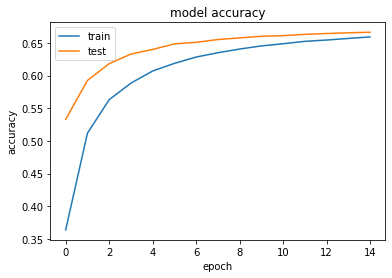

```python
# enocde values to categorical from Int.
encoded_y = to_categorical(y)


# define and fit the final model
model = Sequential()
model.add(Dense(250, input_dim=97, activation='relu'))
model.add(Dropout(0.2))
model.add(Dense(100, activation='relu'))
model.add(Dropout(0.2))
model.add(Dense(50, activation='relu'))
model.add(Dropout(0.2))
model.add(Dense(10, activation='relu'))
model.add(Dense(5, activation='softmax'))


model.compile(loss='categorical_crossentropy', optimizer='adamax', metrics=['acc'])
history = model.fit(X, encoded_y, validation_split=0.33, epochs=15, batch_size=120)



# summarize history for accuracy
plt.plot(history.history['acc'])
plt.plot(history.history['val_acc'])
plt.title('model accuracy')
plt.ylabel('accuracy')
plt.xlabel('epoch')
plt.legend(['train', 'test'], loc='upper left')
plt.show()
```

### Model 7.8

We decrease the batch size to 60 and decrease the number of epochs to 10.

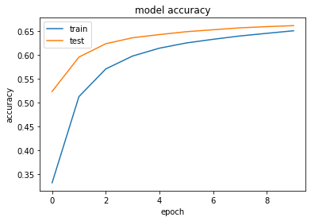

```python
# enocde values to categorical from Int.
encoded_y = to_categorical(y)


# define and fit the final model
model = Sequential()
model.add(Dense(250, input_dim=97, activation='relu'))
model.add(Dropout(0.2))
model.add(Dense(100, activation='relu'))
model.add(Dropout(0.2))
model.add(Dense(50, activation='relu'))
model.add(Dropout(0.2))
model.add(Dense(10, activation='relu'))
model.add(Dense(5, activation='softmax'))


model.compile(loss='categorical_crossentropy', optimizer='adamax', metrics=['acc'])
history = model.fit(X, encoded_y, validation_split=0.33, epochs=10, batch_size=60)

# summarize history for accuracy
plt.plot(history.history['acc'])
plt.plot(history.history['val_acc'])
plt.title('model accuracy')
plt.ylabel('accuracy')
plt.xlabel('epoch')
plt.legend(['train', 'test'], loc='upper left')
plt.show()
```

# Grid Search

Additionally, we will be using the optimizers Adam, Stochastic Gradient Descent and Adamax. The two initializers we have chosen are uniform and random normal.

Each model will be trained for 50 epochs.

### Model 7.1

```python
# enocde values to categorical from Int.
encoded_y = to_categorical(y)


# Function to create model, required for KerasClassifier
def create_model(optimizer='rmsprop', init='glorot_uniform'):
    # create model
    # define and fit the final model
    model = Sequential()
    model.add(Dense(250, input_dim=97, activation='relu', kernel_initializer=init))
    model.add(Dropout(0.2))
    model.add(Dense(100, activation='relu', kernel_initializer=init))
    model.add(Dropout(0.2))
    model.add(Dense(50, activation='relu', kernel_initializer=init))
    model.add(Dropout(0.2))
    model.add(Dense(10, activation='relu', kernel_initializer=init))
    model.add(Dense(5, activation='softmax', kernel_initializer=init))
    model.compile(loss='categorical_crossentropy', optimizer=optimizer, metrics=['acc'])
    return model

# create model
model = KerasClassifier(build_fn=create_model, verbose=0)

# grid search epochs, batch size and optimizer
optimizers = ['adam', 'sgd', 'adamax']
inits = ['uniform', 'random_normal']
batches = [1700, 1800, 1900, 2000, 2100, 2200]
epochs = [50]
# batches = [32, 128, 256, 512, 1024, 2048]

param_grid = dict(optimizer=optimizers, epochs=epochs, batch_size=batches, init=inits)
grid = GridSearchCV(estimator=model, param_grid=param_grid)
grid_result = grid.fit(X, encoded_y, verbose=1)

# summarize results
print("Best: %f using %s" % (grid_result.best_score_, grid_result.best_params_))
means = grid_result.cv_results_['mean_test_score']
stds = grid_result.cv_results_['std_test_score']
params = grid_result.cv_results_['params']

for mean, stdev, param in zip(means, stds, params):
    print("%f (%f) with: %r" % (mean, stdev, param))
```

```
Streaming output truncated to the last 5000 lines.
Best: 0.670765 using {'batch_size': 1900, 'epochs': 50, 'init': 'random_normal', 'optimizer': 'adam'}
0.670695 (0.002783) with: {'batch_size': 1700, 'epochs': 50, 'init': 'uniform', 'optimizer': 'adam'}
0.200035 (0.001784) with: {'batch_size': 1700, 'epochs': 50, 'init': 'uniform', 'optimizer': 'sgd'}
0.658505 (0.004174) with: {'batch_size': 1700, 'epochs': 50, 'init': 'uniform', 'optimizer': 'adamax'}
0.670180 (0.003105) with: {'batch_size': 1700, 'epochs': 50, 'init': 'random_normal', 'optimizer': 'adam'}
0.217160 (0.017301) with: {'batch_size': 1700, 'epochs': 50, 'init': 'random_normal', 'optimizer': 'sgd'}
0.657485 (0.002091) with: {'batch_size': 1700, 'epochs': 50, 'init': 'random_normal', 'optimizer': 'adamax'}
0.670225 (0.003306) with: {'batch_size': 1800, 'epochs': 50, 'init': 'uniform', 'optimizer': 'adam'}
0.200000 (0.001831) with: {'batch_size': 1800, 'epochs': 50, 'init': 'uniform', 'optimizer': 'sgd'}
0.661990 (0.002927) with: {'batch_size': 1800, 'epochs': 50, 'init': 'uniform', 'optimizer': 'adamax'}
0.670240 (0.003407) with: {'batch_size': 1800, 'epochs': 50, 'init': 'random_normal', 'optimizer': 'adam'}
0.218460 (0.011371) with: {'batch_size': 1800, 'epochs': 50, 'init': 'random_normal', 'optimizer': 'sgd'}
0.662130 (0.004069) with: {'batch_size': 1800, 'epochs': 50, 'init': 'random_normal', 'optimizer': 'adamax'}
0.670015 (0.003692) with: {'batch_size': 1900, 'epochs': 50, 'init': 'uniform', 'optimizer': 'adam'}
0.200000 (0.001831) with: {'batch_size': 1900, 'epochs': 50, 'init': 'uniform', 'optimizer': 'sgd'}
0.658925 (0.004102) with: {'batch_size': 1900, 'epochs': 50, 'init': 'uniform', 'optimizer': 'adamax'}
0.670765 (0.003144) with: {'batch_size': 1900, 'epochs': 50, 'init': 'random_normal', 'optimizer': 'adam'}
0.201490 (0.002183) with: {'batch_size': 1900, 'epochs': 50, 'init': 'random_normal', 'optimizer': 'sgd'}
0.658865 (0.003224) with: {'batch_size': 1900, 'epochs': 50, 'init': 'random_normal', 'optimizer': 'adamax'}
0.670125 (0.002915) with: {'batch_size': 2000, 'epochs': 50, 'init': 'uniform', 'optimizer': 'adam'}
0.200000 (0.001831) with: {'batch_size': 2000, 'epochs': 50, 'init': 'uniform', 'optimizer': 'sgd'}
0.659250 (0.003224) with: {'batch_size': 2000, 'epochs': 50, 'init': 'uniform', 'optimizer': 'adamax'}
0.670145 (0.002977) with: {'batch_size': 2000, 'epochs': 50, 'init': 'random_normal', 'optimizer': 'adam'}
0.212815 (0.009147) with: {'batch_size': 2000, 'epochs': 50, 'init': 'random_normal', 'optimizer': 'sgd'}
0.662275 (0.002946) with: {'batch_size': 2000, 'epochs': 50, 'init': 'random_normal', 'optimizer': 'adamax'}
0.670235 (0.002764) with: {'batch_size': 2100, 'epochs': 50, 'init': 'uniform', 'optimizer': 'adam'}
0.200545 (0.001367) with: {'batch_size': 2100, 'epochs': 50, 'init': 'uniform', 'optimizer': 'sgd'}
0.656650 (0.003696) with: {'batch_size': 2100, 'epochs': 50, 'init': 'uniform', 'optimizer': 'adamax'}
0.670565 (0.003243) with: {'batch_size': 2100, 'epochs': 50, 'init': 'random_normal', 'optimizer': 'adam'}
0.213175 (0.011609) with: {'batch_size': 2100, 'epochs': 50, 'init': 'random_normal', 'optimizer': 'sgd'}
0.658100 (0.004146) with: {'batch_size': 2100, 'epochs': 50, 'init': 'random_normal', 'optimizer': 'adamax'}
0.669825 (0.003362) with: {'batch_size': 2200, 'epochs': 50, 'init': 'uniform', 'optimizer': 'adam'}
0.200000 (0.001831) with: {'batch_size': 2200, 'epochs': 50, 'init': 'uniform', 'optimizer': 'sgd'}
0.660205 (0.002839) with: {'batch_size': 2200, 'epochs': 50, 'init': 'uniform', 'optimizer': 'adamax'}
0.670100 (0.003252) with: {'batch_size': 2200, 'epochs': 50, 'init': 'random_normal', 'optimizer': 'adam'}
0.213500 (0.010723) with: {'batch_size': 2200, 'epochs': 50, 'init': 'random_normal', 'optimizer': 'sgd'}
0.661430 (0.003103) with: {'batch_size': 2200, 'epochs': 50, 'init': 'random_normal', 'optimizer': 'adamax'}
```

From the output produced, we can observe that the best model was trained using a batch size of 1900, random normal as the kernel initializer and adam as the optimizer.

However, there is no real difference between the different batch sizes and kernel initializers. The most noticeable difference is the accuracy of Stochastic Gradient Descent compared to Adam and Adamax. This is likely because SGD takes longer to converge the weights of the network than the other two optimizers. Perhaps, if we trained the model for longer with SGD, it would achieve a similar accuracy.

# Final Model

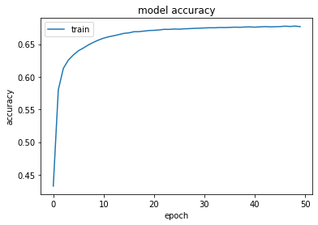

```python
# enocde values to categorical from Int.
encoded_y = to_categorical(y)


# define and fit the final model
model = Sequential()
model.add(Dense(250, input_dim=97, activation='relu', kernel_initializer='random_normal'))
model.add(Dropout(0.2))
model.add(Dense(100, activation='relu', kernel_initializer='random_normal'))
model.add(Dropout(0.2))
model.add(Dense(50, activation='relu', kernel_initializer='random_normal'))
model.add(Dropout(0.2))
model.add(Dense(10, activation='relu', kernel_initializer='random_normal'))
model.add(Dense(5, activation='softmax', kernel_initializer='random_normal'))


model.compile(loss='categorical_crossentropy', optimizer='adam', metrics=['acc'])
history = model.fit(X, encoded_y, epochs=50, batch_size=1900)

# summarize history for accuracy
plt.plot(history.history['acc'])
plt.title('model accuracy')
plt.ylabel('accuracy')
plt.xlabel('epoch')
plt.legend(['train', 'test'], loc='upper left')
plt.show()
```

# Saving Final Model

```python
model.save_weights('/content/drive/MyDrive/UNI/AIIDL/finalModel.hdf5')
```

# Loading Weights

```python
# define and fit the final model
model = Sequential()
model.add(Dense(250, input_dim=97, activation='relu', kernel_initializer='random_normal'))
model.add(Dropout(0.2))
model.add(Dense(100, activation='relu', kernel_initializer='random_normal'))
model.add(Dropout(0.2))
model.add(Dense(50, activation='relu', kernel_initializer='random_normal'))
model.add(Dropout(0.2))
model.add(Dense(10, activation='relu', kernel_initializer='random_normal'))
model.add(Dense(5, activation='softmax', kernel_initializer='random_normal'))


model.compile(loss='categorical_crossentropy', optimizer='adam', metrics=['acc'])
model.load_weights('/content/drive/MyDrive/UNI/AIIDL/finalModel.hdf5')
```

# Evaluating Final Model

### Creating Unseen Data

We create a random dataset of 2000 instances. We have set a random seed to observe the performance of the model with different unseen datasets.

```python
import random
# User values
seed = random.randint(0, 7919)
np.random.seed(seed)
tf.random.set_seed(seed)


features = 97
classes = 5
n = 2000
errors = 0.4
redundant = int(features/4)


# Classification dataset
X, y = make_classification(n_samples=n, n_classes=classes, n_features=features, \
                           random_state = seed,n_informative =20, flip_y=errors, \
                           n_redundant=redundant)

# reshape y to 2D array, it needs to be to append
y = np.reshape(y, (-1, 1))

#add y to x
Xy = pd.DataFrame(np.concatenate((X,y),axis=1))


data = sk.utils.shuffle(Xy, random_state=seed)

dataset = data.values

X = dataset[:,0:97]
y = dataset[:,97:]
# enocde values to categorical from Int.
encoded_y = to_categorical(y)
```

### Evaluating

```python
np.random.seed(seed)
tf.random.set_seed(seed)
model.evaluate(X, encoded_y)
```

```
[1.748063564300537, 0.20200000703334808]
```

From executing the previous 2 blocks of code, we have observed that the accuracy fluctuates between 16% and 24%. This is a big drop in accruacy from the one obtained during the testing of the model.

This could have occured for a various reasons. The model could be overfitted. However, I'm not sure this is the case because the training and testing accuracies are pretty similar. That is, there is very little difference between the two accuracies.

The other reason is that both the training and unseen datasets are randomly generated. Therefore, it is likely that they aren't similar and it is difficult for a neural network to extract the features to correctly classify instances from both datasets.

# Summary and Conclusion

We created a random dataset composed of 200000 instances divided into 5 classes and built a neural network to classify instances from said dataset.

We experimented with models of different depths and widths, adjusted the batch sizes and epochs, trialed different optimizers and kernel intializers to achieve the model with the most accuracy. Also, we applied regularisation techinques like dropout layers to reduce overfitting.

We used grid search to determine which configurations performed best.

Finally, we evaluated the model on unseen data and witnessed a big drop in accuracy. We concluded, that it was likely that the datasets used for training and evaluating, were not similar, making it difficult for a neural network to correctly classify instances from both datasets.